# Sistema de informação Ambulatorial

Author

Fábio Freitas da Silva

## Sistema de Informação Ambulatorial - SIA

DISSEMINAÇÃO DE DADOS EM SAÚDE SIA - SIASUS

### ARQUIVO DE PROCEDIMENTOS AMBULATORIAIS

Dados dos procedimentos ambulatoriais obtidos através dos seguintes instrumentos de registro do SIASUS:

- APAC: Autorização de Procedimentos Ambulatoriais de Alta Complexidade
- BPA-C: Boletim de Produção Ambulatorial Consolidado
- BPA-I: Boletim de Produção Ambulatorial Individualizado
- RAAS-AD: Registro das Ações Ambulatoriais de Saúde - Atenção Domiciliar
- RAAS-PSI: Registro das Ações Ambulatoriais de Saúde - Atenção Psicossocial

O preenchimento dos campos de cada registro do arquivo PA varia conforme o tipo de instrumento que o originou, o que é identificado pelo conteúdo do campo PA_DOCORIG. Assim, quando o campo estiver preenchido com:

- “P”, o registro representa os dados do procedimento principal lançado por meio de uma APAC e “S” para os dados do procedimento secundário;
- “C”, o registro representa os dados dos procedimentos obtidos por intermédio do BPA-C;
- “A”, o registro representa os dados dos procedimentos obtidos por intermédio do RAAS-AD;
- “B”, o registro representa os dados dos procedimentos obtidos por intermédio do RAAS – Psicossocial; e,
- “I”, o registro representa os dados dos procedimentos obtidos por intermédio do BPA - Individualizado.

A quantidade de registros (linhas) varia conforme o tipo de instrumento. A saber:

i. Um instrumento BPA-C gera diversos registros no arquivo PA: um para cada par [código de procedimento, CBO], correspondendo à respectiva linha no instrumento original em papel5;

ii. Um instrumento BPA-I gera diversos registros no arquivo de PA: um para cada atendimento. Há casos de registros de um ou mais atendimentos no BPA-I para o mesmo paciente. Neste caso, pode-se, inclusive, repetir o número da autorização dada pelo gestor de saúde. No BPA-I, este campo é não-obrigatório e, portanto, não é criticado. Assim, devem ser consideradas as limitações quanto à qualidade do seu preenchimento, caso este campo seja utilizado para algum tipo de controle;

iii. Um instrumento APAC gera diversos registros no arquivo PA: um para cada código de procedimento realizado na APAC, seja ele procedimento principal (P) ou secundário (S).

## Metodologia

A análise foi realizada com base nos dados do SIASUS, com as seguintes delimitações:

Foi utilizado o software R para processar os dados, sendo esses obtidos pela biblioteca microdatasus desenvolvida por Saldanha, Bastos e Barcelos (2019).

As variaveis selecionadas foram:

- ‘PA_UFMUN’, # Unidade da Federação + Código do Município onde está localizado o estabelecimento
- “PA_CMP”: Data da Realização do Procedimento / Competência (AAAAMM)
- “PA_CIDPRI”: CID9 Principal (APAC ou BPA-I)
- “PA_CATEND”: Caráter de Atendimento (APAC ou BPA-I)
- “PA_QTDAPR”: Quantidade Aprovada do procedimento

## Análise de dados

As bibliotecas utilizadas foram microdatasus e [tidyverse](https://www.tidyverse.org/). Carregar bibliotecas:

```r
library(tidyverse)
library(janitor)
```

**Tabela 1** - Consultas de caráter eletivo por ano

| ANO | UF_RJ | Campos_Goytacazes |
| --- | --- | --- |
| 2010 | 8.47% (86730) | 0.01% (5) |
| 2011 | 7.94% (81248) | 3.91% (1915) |
| 2012 | 10.46% (106999) | 8.79% (4305) |
| 2013 | 9.86% (100931) | 11.71% (5736) |
| 2014 | 9.41% (96300) | 11.64% (5699) |
| 2015 | 8.81% (90171) | 12.83% (6285) |
| 2016 | 8.68% (88871) | 6.60% (3234) |
| 2017 | 7.02% (71844) | 8.11% (3969) |
| 2018 | 7.63% (78102) | 8.96% (4386) |
| 2019 | 7.91% (80976) | 10.81% (5291) |
| 2020 | 5.55% (56779) | 6.56% (3210) |
| 2021 | 8.25% (84460) | 10.07% (4933) |
| Total | 100.00% (1023411) | 100.00% (48968) |

**Figura 1** - Consultas de caráter eletivo por ano

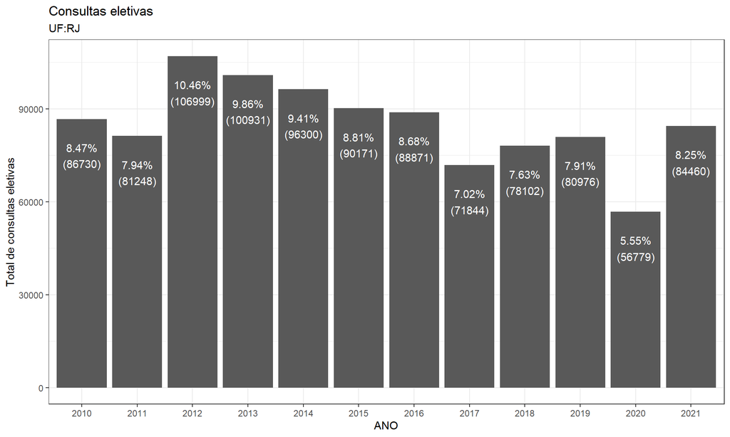

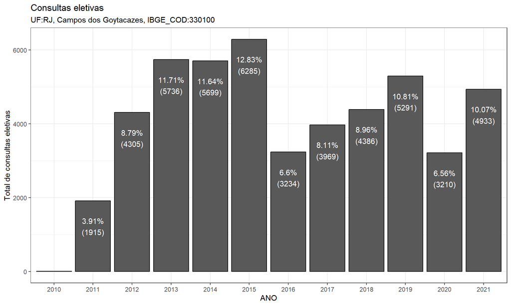

## Referências

SALDANHA, Raphael de Freitas; BASTOS, Ronaldo Rocha; BARCELLOS, Christovam. Microdatasus: pacote para download e pré-processamento de microdados do Departamento de Informática do SUS (DATASUS). Cad. Saúde Pública, Rio de Janeiro , v. 35, n. 9, e00032419, 2019 . Available from http://ref.scielo.org/dhcq3y.